# Introduction to GUSMap (IC class)

Intercross (F2) populations

Timothy P. Bilton

2023-09-12

In this tutorial, we will describe how to use GUSMap to perform linkage mapping and explain some of the functionality available. For this tutorial, we focus on linkage analysis for an F2 or intercross population as implemented in the `IC` class in GUSMap.

For this tutorial, we will use a simulated data set of a full-sib family (F1 population) consisting of 100 offspring, 3 chromosomes and 1000 SNPs to illustrate GUSMap. Although it is more appropriate to analyze this data set using the `FS` class, we use the data set to illustrate `IC` class. The file location to the VCF file (and associated pedigree file) for the data set can be extracted using the `simDS` function.

```r
vcffile <- simDS() # extract filename
vcffile            # filename stored in object vcffile
```

```
#> $vcf
#> [1] "/home/timothy/R/x86_64-pc-linux-gnu-library/4.3/GUSbase/extdata/simDS.vcf"
#>
#> $ped
#> [1] "/home/timothy/R/x86_64-pc-linux-gnu-library/4.3/GUSbase/extdata/simDS_ped.csv"
#>
#> $meta
#> [1] "/home/timothy/R/x86_64-pc-linux-gnu-library/4.3/GUSbase/extdata/simDS_metaInfo.csv"
```

Some important up front comments regarding GUSMap:

1. Having high read depth on the parents (e.g., sequenced more than once) can be hugely helpful to correctly infer the segregation type of more SNPs. However, for the progeny, it is of more value (and cost-efficient) to have more individuals in the family at lower depth than sequence fewer at higher depth.
2. GUSMap is designed for low coverage sequencing data which means that there is no need to pre-filter the data in terms of read depth. Furthermore, GUSMap includes standard filtering steps in terms of minor allele frequency (MAF), missing data and a segregation test (including a few other filters) which means one only needs to input a raw Variant Call Format (VCF) file obtained after the SNP calling processes into GUSMap.

## Loading Data

At present, GUSMap can read in data stored in a Variant Call Format (VCF) file, provided that there is some form of allelic depth information (e.g., the number of reads for the reference and alternate alleles). This is done using the `VCFtoRA` function which takes in the name of a VCF file and converts it into what we call a reference/alternate (RA) file.

```r
# convert VCF file to an RA file
rafile <- VCFtoRA(infilename = vcffile$vcf, direct = "./")
```

```
#> Processing VCF file: Converting to RA format.
#>
#> Found 104 samples
#> 1000 SNPs written
#>
#> Name of RA file:              simDS.vcf.ra.tab
#> Location of RA file:         /home/timothy/R/Package_Development/GUSMap/vignettes/
```

The arguments of the `VCFtoRA` function are:

1. `infilename`: The name of the VCF file.
2. `direct`: Specifies which directory to write the RA file to (relative to the current working directory).

Currently, `VCFtoRA` requires one of the fields **AD**, **AO and RO**, or **DP4** to be present in the VCF file to extract allelic depth information. One other thing to note is that `VCFtoRA` returns the file location of the created RA file.

```r
rafile # file path of RA file
```

```
#> [1] "/home/timothy/R/Package_Development/GUSMap/vignettes/simDS.vcf.ra.tab"
```

The RA file created is a tab-delimited file with columns, **CHROM** (the chromosome name taken from the “#CHROM” column in the VCF file), **POS** (the position of the SNP taken from the “POS” column in the VCF file), and **SAMPLES** which consists of the sampleIDs used in the VCF (columns 10 and above in the VCF file). For example, the first five columns and first four rows of the RA file for the simulated data set are:

| CHROM | POS | P1_1 | P2_1 | P1_2 |
| --- | --- | --- | --- | --- |
| 1 | 866499 | 25,0 | 0,2 | 9,0 |
| 1 | 2070050 | 8,0 | 4,9 | 9,0 |
| 1 | 2232468 | 1,0 | 0,1 | 2,0 |
| 1 | 3459263 | 12,13 | 0,0 | 0,1 |

The entry in the first row and the third column is “25,0” which means that there are 25 reads for the reference allele and no reads for the alternate allele at the SNP on chromosome 1 with position 866499 in sample P1_1. In addition, the fourth row of the third column is “12,13” which menas that there are 12 reads for the reference allele and 13 reads for the alternate allele at the SNP on chromosome 1 with position 3459263 in sample P1_1.

An RA file can then be loaded into R using the `readRA` function.

```r
RAdata <- readRA(rafile = rafile, sampthres = 0.01, excsamp = NULL)
```

The arguments of the `readRA` function are:

1. `rafile`: Name of the RA file to be read in.
2. `sampthres`: Specifies the minimum sample depth of an individual before it is removed.
3. `excsamp`: Specifies IDs of any samples in the RA data set to be discarded (for problematic samples to be removed). The input for `excsamp` must correspond to the sample IDs in the RA file.

The RA data is now stored as an `RA` object.

```r
class(RAdata)
```

```
#> [1] "RA" "R6"
```

Summary information of the RA object can be displayed by printing the object.

```r
RAdata
```

```
#> Data Summary:
#>  Data file:      /home/timothy/R/Package_Development/GUSMap/vignettes/simDS.vcf.ra.tab
#>  Mean Depth:     5.02
#>  Mean Call Rate: 0.85
#>  Number of...
#>    Samples:      104
#>    SNPs:     1000
#>    Reads:        522400
```

## Linkage mapping with GUSMap

In this section, we will discuss linkage mapping using GUSMap. The main steps to the process are:

1. Create a F2 (intercross) populations and perform appropriate filtering
2. Constructing linkage groups
3. Ordering markers across each linkage group
4. Computing maps for the ordered linkage groups

More details of the mathematics underpinning the methods in GUSMap can be found in Bilton et al. (2018). In the following sections, we shall discuss how each of these steps are performed in GUSMap.

### Constructing a intercross population

Construction of a intercross (F2) population object is achieved using the `makeIC` function. At present, GUSMap only uses information from the progeny (F2 individuals in an F2 population). If parents and/or grandparents are included in the VCF that is read into GUSMap (as described previously), then they should be excluded in the creation of the intercross population. For the example data set, there are two samples for the maternal parent and two samples for the paternal parent. Sample IDs from the RA object can be extracted using the `$extractVar`

```r
samID = RAdata$extractVar("indID")$indID
head(samID)
```

```
#> [1] "P1_1"   "P2_1"   "P1_2"   "P2_2"   "F1_001" "F1_002"
```

The first four IDs (“P1_1”,“P2_1”,“P1_2”,“P2_2”) correspond to the two parents, while the remainder correspond to the progeny (“F1_001” to “F1_100”). We proceed to create the IC population using only the progeny samples as follows:

```r
progeny = samID[-c(1:4)]
mySpecies <- makeIC(RAobj = RAdata, samID = progeny,
                      filter = list(MAF = 0.05, MISS = 0.5,
                        BIN = 100, DEPTH = 5, PVALUE = 0.01, MAXDEPTH=500))
```

```
#> -------------
#> Processing Data.
#>
#> Filtering criteria for removing SNPs:
#> Minor allele frequency (MAF) < 0.05
#> Percentage of missing genotypes > 50%
#> Distance for binning SNPs <= 100 bp
#> Read depth associated with at least one parental genotype <= 5
#> P-value for segregation test < 0.01%
#> Average SNP depth is > 500
#>
#> -------------
#> Summary:
#>
#> Number of SNPs remaining after filtering: 174
#> Number of progeny: 100
```

The `makeIC` function takes an `RA` object, creates an intercross population and performs filtering on the data.

Again, more details of these various filter types is available in the package documentation of the `makeIC` function.

### Linkage Groups

##### Computing 2-point recombination fraction estimates

Linkage group formation in GUSMap is based on 2-point recombination fraction estimates and associated LOD scores between all pairs of SNPs. These are computed using the function `$rf_2pt`.

```r
mySpecies$rf_2pt(nClust = 3)
```

```
#>
#> Computing 2-point recombination fraction estimates ...
#> Both informative SNPs
```

The `$rf_2pt` function is parallelized to reduce computational time, where the `nClust` argument specifies how many cores to use in the parallelization. Be careful not to set this to more than what is available on your computer. Note: this step can take some time, especially if there are a large number of SNPs in your data set.

**Hint**: Since computing the 2-point recombination fractions can take quite long, it is best to save the IC object as a R data file using the `save` function. For example:

```r
save(mySpecies, file="ICobject.Rdata")
```

Once the 2-point recombination fraction estimates and associated LOD scores have been computed, we can plot the resulting recombination fraction estimates on a heatmap.

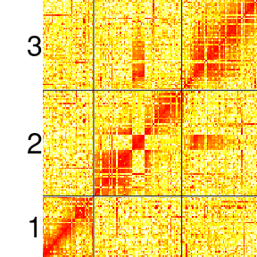

```r
# plot 2-point rf matrix for BI and MI SNPs
mySpecies$plotChr(mat = "rf", lmai=0.5)
```

Heatmaps are helpful for examining genome assemblies if the SNPs where called using a reference genome. For our example, we see that the middle section of chromosome 2 should actually be with chromosome 3, and that the last quarter of chromosome 1 needs to be inverted (that is the marker order need to be reversed). Furthermore, there are a number of SNPs that are clearly on the wrong chromosome and should be mapped to one of the other chromosomes. For *de novo* assemblies, one can still plot the 2-point recombination fraction estimates although the resulting plot should look fairly random and so is usually not very informative.

One can also plot the matrix of 2-point LOD scores.

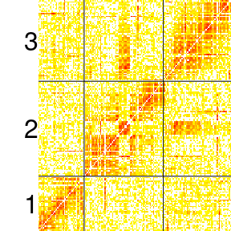

```r
# plot 2-point LOD matrix for BI, PI and MI SNPs
mySpecies$plotChr(mat = "LOD", lmai=0.5)
```

##### Forming linkage groups

Using our 2-point recombination fraction estimates and LOD scores, we can proceed to forming linkage groups.

```r
mySpecies$createLG(LODthres = 10, nComp = 10)
```

```
#> Combined Linkage Group Summary:
#>  LG    BI  TOTAL
#>  1     59  59
#>  2     51  51
#>  3     12  12
#>  4     16  16
#>  5     5   5
#>  6     5   5
#>  7     7   7
#>  TOTAL 155 155
```

The performance of the linkage grouping algorithm is controlled by the parameters `LODthres` and `nComp`. Details of these arguments and how the linkage groups are formed is explained in the package documentation at:

```r
?`$createLG`
```

Once the linkage groups have been formed, it is a good idea to look how well the grouping has performed by examining the heatmap of the 2-point recombination fraction estimates with the SNPs grouped according to the linkage groups. This can be done using the `$plotLG` function.

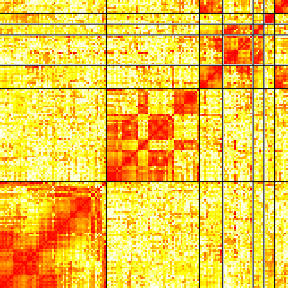

```r
mySpecies$plotLG(interactive = F, LG = NULL)
```

The heatmap shows that there are seven linkage groups. We would expect there to be three linkage groups as there are 3 chromosomes. The heatmap suggests that linkage groups 3, 4, 5 and 7 are actually one single linkage group due to the low recombination fraction estimates between linkage groups. It is also possible that linkage group 6 is actually part of linkage group 1, however there is less evidence of this from the 2-point recombination fraction heatmap.

Note:

- Setting `interactive=TRUE` for the `$plotLG` function results in an interactive plot being plotted. Interactive plots make interrogating the recombination fraction (or LOD) plot and finding problematic SNPs easier. We have set this to `FALSE` in this tutorial to keep the size of this file small. In your session, try producing the interactive plot.
- At present, interactive plots generally work on a small number of SNPs (usually no more than 1000), so depending on the size of your linkage groups, you may need to plot each linkage group separately. You can use the `LG` argument to plot specific linkage groups.

##### Editing Linkage Groups

There are a number of functions in GUSMap for editing linkage groups. Ideally, one should obtain as many linkage groups as the number of chromosomes the species is known to have. However, in practice, the number of linkage groups may be more, or less, than the number of chromosomes depending on the LOD threshold used and whether there is enough linkage between SNPs on the same chromosome to group all the SNPs located on the same chromosome together in the same linkage group.

For our simulated data, we had seven linkage groups. From the heatmaps above, we see that linkage groups 3, 4, 5 and 7 appear part of the same linkage group. We can merge these linkage groups using the `$mergeLG` function.

```r
mySpecies$mergeLG(LG = c(3,4,5,7))
mySpecies$print(what = "LG")
```

```
#> Combined Linkage Group Summary:
#>  LG    BI  TOTAL
#>  1     59  59
#>  2     51  51
#>  3     40  40
#>  4     5   5
#>  TOTAL 155 155
```

Note that after merging linkage groups, the linkage group which was previous denoted 6 is now denoted by 4. We could also merge this linkage group with linkage group 1, as suggested by moderately low recombination fraction estimates between the linkage groups. However, since we are not confident of this based on the heatmap, we decide to remove linkage group 4, which can be done using the `$removeLG` function.

```r
mySpecies$removeLG(LG = 4)
mySpecies$print(what = "LG")
```

```
#> Combined Linkage Group Summary:
#>  LG    BI  TOTAL
#>  1     59  59
#>  2     51  51
#>  3     40  40
#>  TOTAL 150 150
```

Alternatively, one could have also have removed the linkage group by removing all the SNPs present in the linkage group using the `$removeSNP` function.

```r
mySpecies$removeSNP(snps = c(36,27,32,28,131))
```

Note that the `$removeSNP` function is more useful for removing SNP(s) from a linkage group if they appear problematic without deleting the entire linkage group.

**Note:** At this stage there is no undo functionality in GUSMap. So, once you have removed a SNP or linkage group, or merge two linkage groups, you cannot reverse what you have done. However, in the case where you want to undo edits to your linkage group, the best thing to do is to recreate the linkage groups using the `$createLG` function and proceed as you were doing before (and hence it helps to save you code in a script).

In practice, our choice for the LOD threshold previously might have been too high to begin with. Thus, we can also attempt to obtain the optimal number of linkage groups by trying different values for `LODthres` in the `$createLG` function.

```r
mySpecies$createLG(LODthres = 8)
```

```
#> Combined Linkage Group Summary:
#>  LG    BI  TOTAL
#>  1     67  67
#>  2     53  53
#>  3     43  43
#>  TOTAL 163 163
```

As we can see, a LOD threshold of 8 obtains the desired number of linkage groups in one go. In practice, however, there are likely to be lots small linkage groups (in addition to large linkage groups that correspond to the linkage groups) that either need to be merged with other linkage groups or removed using the functions described eariler.

### Ordering Linkage Groups

Once we are happy with the linkage groups we have formed, we can proceed to order the SNPs in each linkage group. In GUSMap, marker ordering is performed using the multidimensional scaling (MDS) approach as described by Preedy and Hackett (2016) and is implemented in the `$orderLG` function.

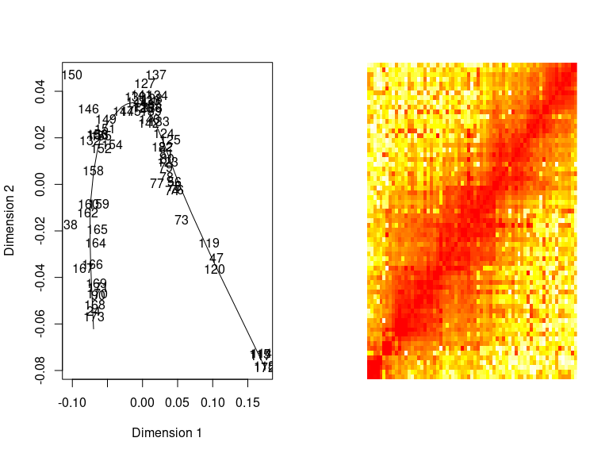

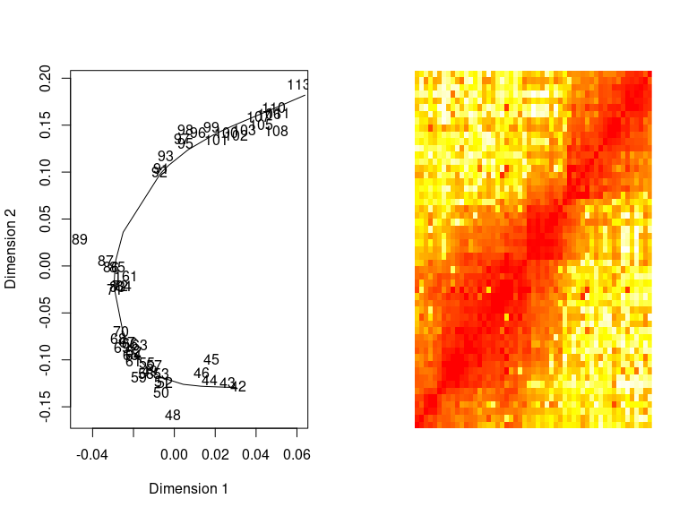

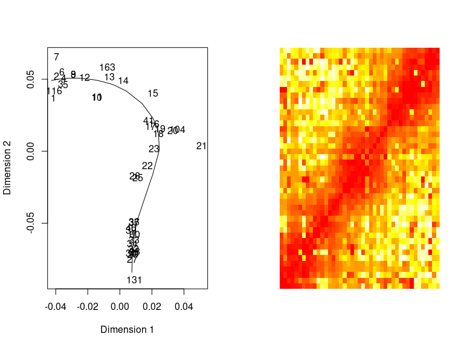

```
#> Using the MDS scaling algorithm to order SNPs.
#>  Preedy & Hackett (2016). Theor Appl Genet. 129:2117-2132
```

```r
mySpecies$orderLG(mapfun = "haldane", weight = "LOD2", ndim = 30)
```

The two plots produced by the `$orderLG` function are:

1. The first two dimensions of the components of the MDS.
2. The heatmap of the 2-point recombination fraction for all SNPs on the linkage group ordered according to the MDS algorithm.

These plots are helpful for examining how well the algorithm has ordered the SNPs. Details of the MDS algorithm are given in Preedy and Hackett (2016) and information for the arguments `mapfun` and `weight` can be found in the package documentation (The default arguments tend to give the best results).

```r
?`$orderLG`
```

### Compute Linkage Maps

Now that we have finished ordering and tidying up the linkage groups, we proceed to compute the linkage maps using the `$computeMap` function.

```r
mySpecies$computeMap(chrom = NULL, nThreads = 3, rfthres=0.1)
```

```
#> Computing recombination fractions:
#> Linkage Group:  1
#> RF-5 is 0.1445 (between SNPs 114 and 47)
#> RF-8 is 0.1005 (between SNPs 119 and 73)
#> RF-23 is 0.5286 (between SNPs 124 and 133)
#> Linkage Group:  2
#> RF-33 is 0.4376 (between SNPs 87 and 89)
#> Linkage Group:  3
#> RF-17 is 0.3075 (between SNPs 15 and 17)
#> Warning in log(1 - 2 * rf): NaNs produced
#> Linkage Map Summaries:
#>  LG    BI  DIST   ERR
#>  1     67  NaN    0.00606
#>  2     53  206.69 0.00412
#>  3     43  133.58 0.00518
#>  TOTAL 163 340.27
```

The `$computeMap` function has a number of arguments but the main ones are `chrom` which specifies which linkage group to compute linkage maps for and `nThreads` which specifies the number of threads to use in the computation of the likelihood (using OpenMP if available). The resulting output gives the overall map distances and sequencing error estimates for each chromosome (in addition to the linkage group information).

```r
## remove SNP 173
mySpecies$removeSNP(c(124,133,89))
## Recompute linkage map
mySpecies$computeMap(chrom = c(1,2), nThreads = 3, rfthres=0.1)
```

```
#> Computing recombination fractions:
#> Linkage Group:  1
#> RF-5 is 0.1445 (between SNPs 114 and 47)
#> RF-8 is 0.1005 (between SNPs 119 and 73)
#> Linkage Group:  2
#> RF-25 is 0.3567 (between SNPs 70 and 84)
#> RF-33 is 0.1103 (between SNPs 87 and 92)
#> Linkage Map Summaries:
#>  LG    BI  DIST   ERR
#>  1     65  133.75 0.00613
#>  2     52  157.04 0.00413
#>  3     43  133.58 0.00518
#>  TOTAL 160 424.37
```

The overall map distances now look reasonable and although there are a few largish recombination fraction estimates, they are not a concern as there appears to be large distances between SNPs at these sections of the maps.

GUSMap has a couple of functions for quickly examining the linkage maps computed. The first function is to plot the linkage maps.

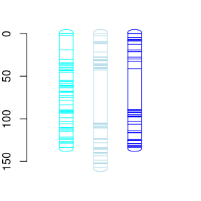

```r
mySpecies$plotLM(LG = NULL, fun = "haldane", col=c("cyan","lightblue","blue"))
```

The arguments for the `$plotLM` function are:

- `LG`: The indices of the linkage groups to be plotted.
- `fun`: The mapping function to use. Currently only the Haldane, Kosambi and Morgan mapping functions are available.
- `col`: A vector of colors for the linkage maps.

In addition, we can also examine the order of the SNPs across the linkage groups relative to the original assembly.

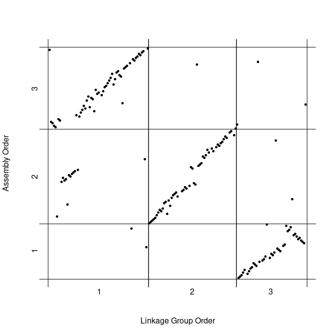

```r
mySpecies$plotSyn()
```

From the synteny plot above, we see that linkage group 1 corresponds to chromosome 3, linkage group 2 to chromosome 2 and linkage group 3 to chromosome 1. Furthermore, the plot shows that the linkage mapping analysis has moved the middle section of chromosome 2 to chromosome 3 (linkage group 1) and that it has inverted the SNP order at the end of chromosome 1 (linkage group 3).

Finally, one can extract the results of the linkage analysis in GUSMap by writing the results to a file using the `$writeLM` function.

```r
mySpecies$writeLM(file = "mySpecies", inferGeno = TRUE)
```

This is allows users to produce their own custom plots in whatever software they are familiar with. The `inferGeno` argument indicates whether to compute the most likely haplotype for each chromosome in each individual, which is appended to the file as columns. For details of the information given in the file, see the package documentation.

```r
?`$writeLM`
```

# References

Bilton, Timothy P., Matthew R. Schofield, Michael A. Black, David Chagné, Phillip L. Wilcox, and Ken G. Dodds. 2018. “Accounting for Errors in Low Coverage High-Throughput Sequencing Data When Constructing Genetic Maps Using Biparental Outcrossed Populations.” *Genetics* 209 (1): 65–76. https://doi.org/10.1534/genetics.117.300627.

Preedy, K. F., and C. A. Hackett. 2016. “A Rapid Marker Ordering Approach for High-Density Genetic Linkage Maps in Experimental Autotetraploid Populations Using Multidimensional Scaling.” *Theoretical and Applied Genetics* 129 (11): 2117–32. https://doi.org/10.1007/s00122-016-2761-8.